# Usage example

## Introduction

This document illustrates an example of how the `epitopes` package can be used to create an organism-specific epitope predictor. We will use data related to the nematode *O. volvulus* as our target pathogen.

## Initial setup:

The `epitopes` package provides functions to download, extract, consolidate and pre-process epitope data from the [Immune Epitope Database (IEDB)](http://www.iedb.org/), together with protein data (retrieved from NCBI and Uniprot) and taxonomy information for each pathogen (also from NCBI).

This initial part is quite time-consuming, but it only needs to be done once, at the start of any project (or possibly once every few months, to get updated versions of the database). Once these are retrieved and saved, they can be loaded using simple `readRDS()` calls.

```r
library(epitopes)

# Download the full IEDB export into a given folder "XYZ"
epitopes::get_IEDB(save_folder = "XYZ")

# Extract only the linear B-cell epitopes from the IEDB export and save the
# result to folder "ABC"
epitopes <- epitopes::get_LBCE(data_folder = "XYZ",
                               ncpus = parallel::detectCores() - 2,
                               save_folder = "ABC")

# Retrieve the relevant proteins and save them into the same folder "ABC"
proteins <- epitopes::get_proteins(uids = unique(epitopes$protein_id),
                                   save_folder = "ABC")

# Retrieve a taxonomy list for all pathogens and save it into the same folder "ABC"
taxonomy <- epitopes::get_taxonomy(uids = unique(epitopes$sourceOrg_id),
                                   save_folder = "ABC")
```

## Merge datasets and filter observations

The first step is to enrich the epitope data with protein information. This step is also useful to perform some initial filtering of the epitopes. In this example, assume that:

- We’re interested only in peptides between 8 and 25 amino acids long.
- Both *Exact epitopes* and *Epitope-containing regions* should be considered.
- If there’s a mismatch between the stated position of the peptide (from the *epitopes* data) and the corresponding sub-sequence on the protein (from the *proteins* data) then the sequence should not be considered.
- If a given peptide has conflicting labels (emerging from distinct assays, for instance) then its class should be determined as the most frequent value.

```r
# Join proteins into epitope dataset
jdf <- epitopes::prepare_join_df(epitopes, proteins,
                                 min_epit        = 8,
                                 max_epit        = 25,
                                 only_exact      = FALSE,
                                 pos.mismatch.rm = "all",
                                 set.positive    = "mode")
```

The next step is to filter out only the observations correspoding to the pathogen of interest, based on its taxonomy ID (the function retains all lower-order taxIDs, so if you pass e.g. a genus taxID it will retain all organisms from that genus). We can also use function `filter_epitopes()` to filter observations by the host ID or to indicate whether we want to remove some specific ID from the list (e.g., remove a specific strain).

```r
OrgID   <- 6282 # Pathogen: O. volvulus
hostIDs <- 9606 # Host: humans

# Filter data
jdf <- epitopes::filter_epitopes(jdf,
                                 orgIDs   = OrgID,
                                 hostIDs  = hostIDs,
                                 tax_list = taxonomy)
```

## Prepare a windowed representation and calculate features:

The next step for preparing the data is to project the data into a windowed representation, in which each amino acid position of each labelled peptide from the epitope data will be represented by a fixed-length window of its local neighbourhood. By default, the window size is set as `2 * min_epit - 1`, to guarantee that the majority of positions in the window will always be part of a labelled peptide.

Feature calculation is still a relatively time-consuming part of the pipeline (increasing speed is high in our to-do list). The current version of the `epitopes` package calculates the following features:

- Percent composition of the sequence in terms of:
  - Individual AA (20 features)
  - Dipeptides (400 features)
  - Conjoint triads (343 features)
  - AA types (Tiny, Small, Aliphatic, Aromatic, NonPolar, Polar, Charged, Basic and Acidic - 9 features).
- AA descriptors, averaged over the window: Cruciani properties, Kidera factors, Z scales, FASGAI indices, T scales, VHSE scales, ProtFP descriptors, ST Scales, BLOSUM indices, and MS-WHIM scores (66 features). These features come from package Peptides.
- Total molecular weight of the window (1 feature).
- Total number of Carbon, Hydrogen, Nitrogen, Oxygen and Sulphur atoms in the sequence (5 features).
- Entropy of the distribution of AA residues in the sequence (1 feature).

Future versions of `epitopes` are planned to include structure-based features, protein-level features and others. The package is structured in a way to easily incorporate the calculation of new features.

```r
# Prepare windowed representation
wdf <- epitopes::make_window_df(jdf, ncpus = parallel::detectCores() - 2)

# Calculate features
wdf <- epitopes::calc_features(wdf, max.N = 2, ncpus = parallel::detectCores() - 2)
```

# Split Model development and hold-out sets

Before training our organism-specific predictor, we isolate a subset of the data to be able to get a good estimate of the generalisation performance of the model. Although cross-validation could potentially be used, it is slightly harder to prevent data-leakage between folds, so we opted for a hold-out set approach.

If BLASTp is installed locally in your machine (check [here](https://blast.ncbi.nlm.nih.gov/Blast.cgi?PAGE_TYPE=BlastDocs&DOC_TYPE=Download) for installation details), function `split_epitope_data()` can split the data at the protein level using *coverage* and *similarity* thresholds to ensure that similar proteins are always placed under the same split, reducing the chances of leakage between the training and hold-out sets.

```r
library(seqinr)

prots <- proteins[proteins$UID %in% unique(jdf$protein_id), ]

if(!dir.exists("./BLASTp")) dir.create("./BLASTp")
fn <- "./BLASTp/prots.fasta"
seqinr::write.fasta(as.list(prots$TSeq_sequence), names = prots$UID,
                    file.out = fn, as.string = TRUE, nbchar = 100000)

# Run BLASTp to determine protein similarities
system(paste0("makeblastdb -in ", fn, " -dbtype prot"))
system(paste0("blastp -query ", fn, " -db ", fn, " -seg no ",
              "-outfmt '6 qseqid sseqid length qlen ",
              "slen nident pident qcovhsp mismatch gaps qstart ",
              "qend sstart send evalue score' > ", fn, "-BLAST"))

# Split data into training/test/final validation sets, splitting by protein ID
# and using BLASTp to minimise similarities across splits
splits <- epitopes::split_epitope_data(wdf, split_level = "prot",
                                       split_perc = c(75, 25),
                                       split_names = c("01_training", "02_holdout"),
                                       save_folder = "./splits",
                                       blast_file = "./BLASTp/prots.fasta-BLAST",
                                       coverage_threshold = 60, identity_threshold = 60)
```

## Fit predictive model

Any classification strategy can now be used to generate a predictor. The `epitopes` package provides a quick interface to the Random Forest implementation from ranger, which is quite versatile. Check the documentation of function `fit_model()` to check how to pass specific hyperparameters to ranger’s RF routines.

```r
# Fit model using ranger's standard parameters
my.model <- epitopes::fit_model(data.train = splits[[1]]$wdf,
                                data.test  = splits[[2]]$wdf,
                                rnd.seed   = 1234,
                                ncpus      = parallel::detectCores() - 2)

# Calculate performance
my_perf <- epitopes::calc_performance(truth = splits[[2]]$wdf$Class,
                                      pred  = my.model$rf_class,
                                      prob  = my.model$rf_probs,
                                      ret.as.list = TRUE)
```

To check the model performance:

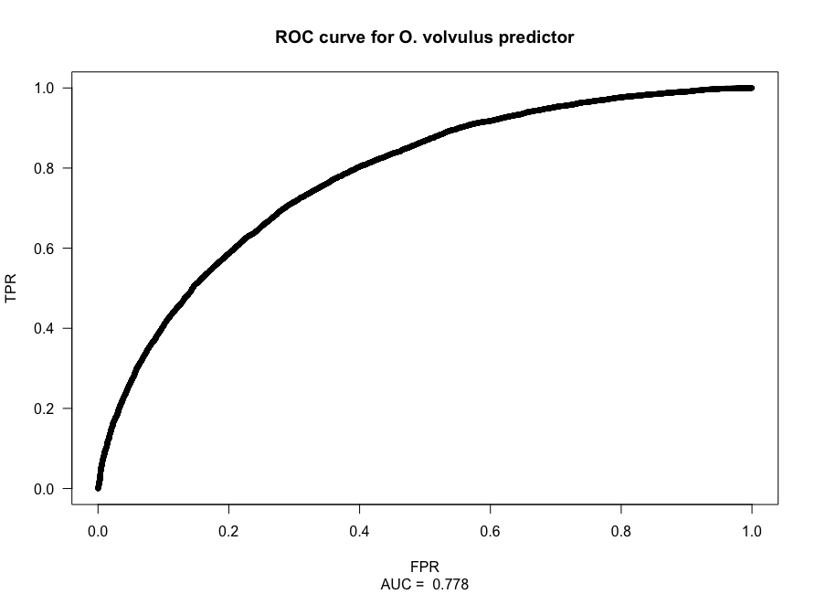

```r
# Plot ROC curve
plot(my_perf$fpr, my_perf$tpr, type = "p", pch = 20, las = 1,
     xlab = "FPR", ylab = "TPR",
     main = "ROC curve for O. volvulus predictor",
     sub = paste("AUC = ", signif(my_perf$auc, digits = 3)))

print(unlist(my_perf[c(5:12)]))
```

[output not shown]

## Apply to a new sequence

To apply the predictor (which is saved under `my.model$rf_model`) to a new protein, you just need to:

- Create a windowed representation of the protein
- Calculate feature
- Pass the protein through the model using the `predict` function

```r
# Get the first protein from the hold-out set as an example:
myprot <- proteins[proteins$UID == splits[[2]]$wdf$Info_protein_id[1]]

# Make windowed representation:
myprot_w <- epitopes::make_window_df(myprot,
                                     window_size = nchar(splits[[2]]$wdf$Info_window_seq[1]))
myprot_w <- epitopes::calc_features(myprot_w, max.N = 2,
                                    ncpus = parallel::detectCores() - 2)

# Get predictions from the model
myprot_w <- as.data.frame(myprot_w)[, which(!grepl("Info_", names(myprot_w)))]
preds    <- stats::predict(my.model$rf_model,
                           data = myprot_w)
```

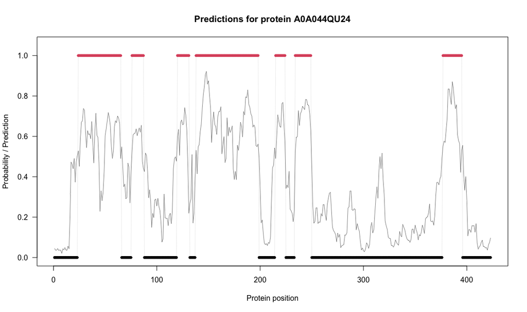

```r
# Smooth predictions (to remove very short positive sequences)
myclass <- epitopes::smooth_predictions(as.numeric(preds$predictions[, 2] > 0.5),
                                        minsize = 8)

plot(preds$predictions[, 2], type = "l", lwd = .5, las = 1,
     main = paste("Predictions for protein", myprot$UID[1]),
     xlab = "Protein position",
     ylab = "Probability / Prediction",
     ylim = c(0, 1.05))
points(myclass, type = "p", pch = 20, col = myclass + 1)
points(myclass, type = "l", lwd = .3, col = "#77777777")
```